# Cyclic/Periodic Mathematical Model

Riley Fiske, Iyanu Lamina

# **The Cyclic/Periodic Mathematical Model**

## Read in the Dataset and wrangle data into usable format

```r
suntimes <- read.csv("https://raw.githubusercontent.com/gmtanner-cord/DATA316/main/Data/MoorheadSunriseSunset.csv",stringsAsFactors = TRUE)

suntimes$Date <- as.Date(suntimes$Date,format="%m/%d/%Y") #https://www.statology.org/convert-strings-to-dates-in-r/
suntimes <- suntimes %>% mutate(Day=as.POSIXlt(Date)$yday) #https://rc2e.com/stringsanddates
suntimes$Day <- as.integer(suntimes$Day)

suntimes <- suntimes %>% mutate(SunriseHR = floor(Sunrise.CST / 100))  %>%
  mutate(SunriseMin = Sunrise.CST - 100 * SunriseHR) %>%
mutate(SunsetHR = floor(Sunset.CST / 100))  %>%
  mutate(SunsetMin = Sunset.CST - 100 * SunsetHR) %>%
  mutate(SunriseTime = SunriseHR + SunriseMin / 60) %>%
 mutate(SunsetTime = SunsetHR + SunsetMin / 60)
```

## The Cyclic/Period Model Overview

The cyclic model is a mathematical model used to capture a trend over a period that repeats itself. Mathematically, these types of trends are typically represented using a sine wave, and the cyclic model uses this. The equation $y = a sin(bt - c) + d$ is used to model this, with the parameters *a*, *b*, *c*, & *d* tuned using the nls() function.

Cyclical models are useful for modeling trends that, as the name implies, cycle. The trend repeats itself over time by a given interval. For that reason, the input is almost always time $t$, whether that $t$ be in minutes, hours, days, months, or years. Some real life examples of this would be temperature at 8am over the course of the year, number of birds in the sky in a specific city everyday over the course of the year, or the example we will use, the sunrise and sunset times everyday over the course of one year.

## Parameter Interpretation and Mathematical Characteristics

The four tuning parameters can be described as follows:

- *a* is the amplitude of the sine wave
- *b* is the period times $2\pi$
- *c* is the phase/horizontal shift
- *d* is the vertical shift

[Source](http://jwilson.coe.uga.edu/EMAT6680Fa09/Gonterman/Gonterman1/Gonterman1.html)

Additionally, the domain of the model is by default $[0,2\pi]$, but can be manipulated using the *b* parameter. The maximum of the function is $d + a$ and the minimum is $d - a$. The range of the model is thus contained between this maximum and minimum.

## [Desmos Demonstration](https://www.desmos.com/calculator/6tysciq4cs)

# **Application**

## Visualization of Moorhead Sunrise/Sunset Data

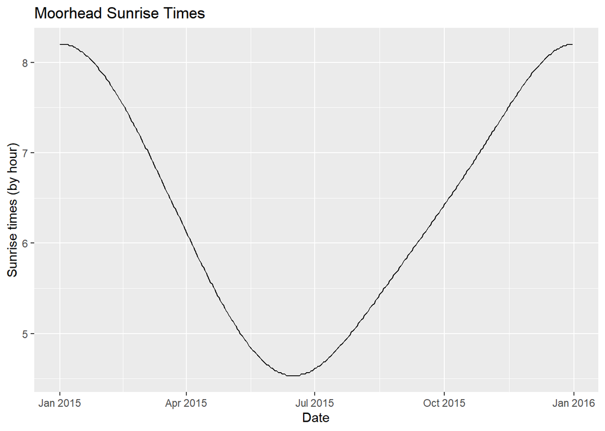

```r
ggplot(suntimes,aes(x=Date))+
  labs(title = "Moorhead Sunrise Times",
       x = "Date",
       y ="Sunrise times (by hour)")+
  geom_line(aes(y=SunriseTime))
```

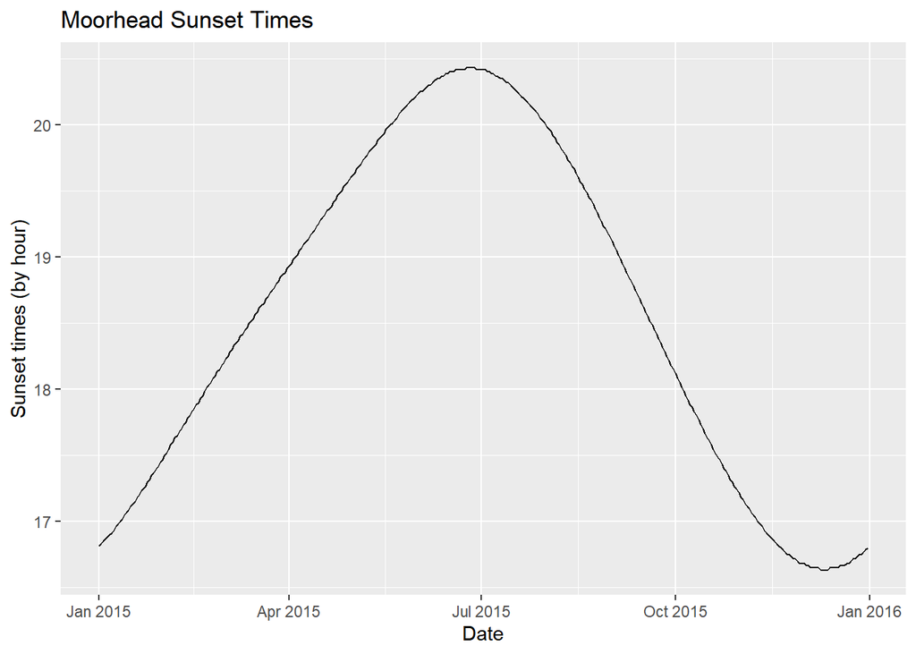

```r
ggplot(suntimes,aes(x=Date))+
  labs(title = "Moorhead Sunset Times",
       x = "Date",
       y ="Sunset times (by hour)")+
  geom_line(aes(y=SunsetTime))
```

Both the Sunrise and Sunset times seem to follow some sort of cyclical trend. Let’s try and fit a function to the trend. (Reminder: The equation for a cyclical trend is $y = a sin(bt - c) + d$)

## Our First Model

We will use the nls function to predict SunriseTime using Day and our four parameters *a*, *b*, *c*, & *d*. We will then see if the model follows our data.

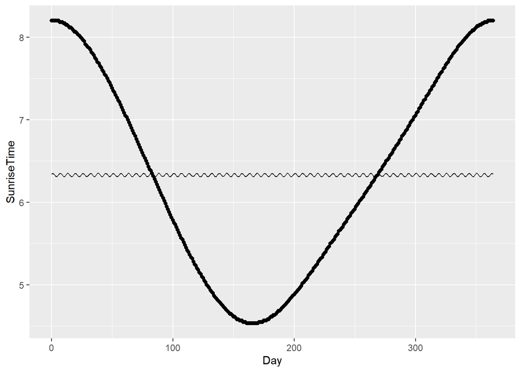

```r
mod.cyc.sunrise <- nls(SunriseTime ~ a * sin((b * Day) + c) + d,data=suntimes,start=list(a=1,b=1,c=1,d=1))

suntimes$sunrise_predicted <- predict(mod.cyc.sunrise)

ggplot(suntimes,mapping=aes(x=Day,y=SunriseTime)) +
  geom_point() +
  geom_line(mapping=aes(x=Day,y=sunrise_predicted))
```

It clearly does not follow the desired fit, but if we give it better guesses for where to start for parameters, we should be able to improve the trend.

Recall that *b* is the period * $2\pi$, and we want our period to be $\frac{2\pi}{365}$. If $b=\frac{1}{2\pi*9.24}$, the period is roughly 365 days. *d* is such that it is equally distanced from the minimum and the maximum, so let $d=\frac{max(SunriseTime)+min(SunriseTime)}{2}$. *a* is the distance from *d* to the maximum and *d* to the minimum, so let $a=max(SunriseTime)-d=d-min(SunriseTime)$. Using desmos with the above calculated values, we can estimate *c* to be about 4.7, which puts the maximum at $t=0$.

Therefore, *a* = 1.8633, *b* = 0.01722, *c* = 4.7, and *d* = 6.33667.

## Revised Model for Sunrise

Let’s try our model again using these values.

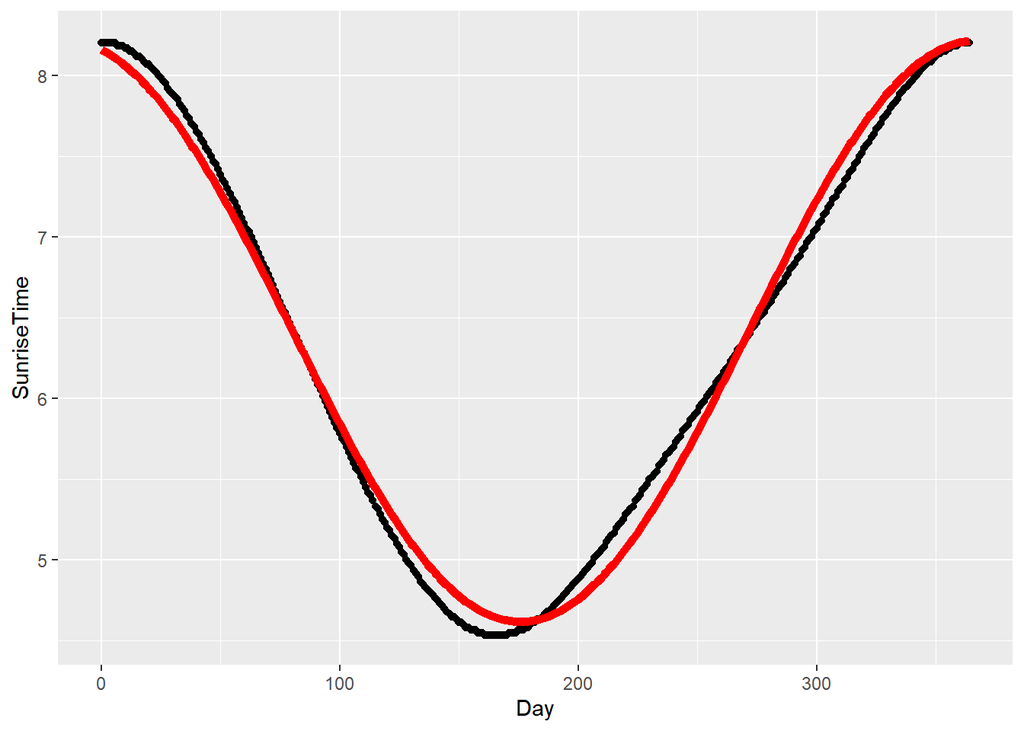

```r
mod.cyc.sunrise <- nls(SunriseTime ~ a * sin((b * Day) + c) + d,data=suntimes,start=list(a=1.8633,b=.01722,c=4.7,d=6.336667))

suntimes$sunrise_predicted <- predict(mod.cyc.sunrise)

ggplot(suntimes,mapping=aes(x=Day,y=SunriseTime)) +
  geom_point() +
  geom_line(mapping=aes(x=Day,y=sunrise_predicted),color="red",linewidth=2)
```

This fits much better. Let’s look at the parameters that it chose for us.

```r
summary(mod.cyc.sunrise)
```

```
##
## Formula: SunriseTime ~ a * sin((b * Day) + c) + d
##
## Parameters:
##   Estimate Std. Error t value Pr(>|t|)
## a -1.79842    0.01288  -139.6   <2e-16 ***
## b  0.01642    0.00013   126.3   <2e-16 ***
## c  4.96627    0.02331   213.1   <2e-16 ***
## d  6.41766    0.01645   390.2   <2e-16 ***
## ---
## Signif. codes:  0 '***' 0.001 '**' 0.01 '*' 0.05 '.' 0.1 ' ' 1
##
## Residual standard error: 0.1225 on 361 degrees of freedom
##
## Number of iterations to convergence: 8
## Achieved convergence tolerance: 4.825e-06
```

```r
summary(mod.cyc.sunrise)$coefficients
```

```
##      Estimate   Std. Error   t value      Pr(>|t|)
## a -1.79842395 0.0128846742 -139.5785 3.452354e-316
## b  0.01641917 0.0001300179  126.2839 8.249055e-301
## c  4.96627111 0.0233072779  213.0781  0.000000e+00
## d  6.41766364 0.0164478870  390.1816  0.000000e+00
```

```r
a <- summary(mod.cyc.sunrise)$coefficients[1,1]
b <- summary(mod.cyc.sunrise)$coefficients[2,1]
c <- summary(mod.cyc.sunrise)$coefficients[3,1]
d <- summary(mod.cyc.sunrise)$coefficients[4,1]
```

To put these in context:

- *a* = -1.8 which is the amplitude, or the distance from the average of our minimum and maximum sunrise times, which means that time is 1 hour and 48 minutes
- *b* = .0164, which is the period times $2\pi$ of our function, or how long it takes to get from the maximum to the maximum again (one full cycle)
- *c* = 4.966, or the horizontal adjustment since a sine graph would typically start at *d* since $sin(0)+d=0+d=d$
- *d* = 6.417, or the vertical adjustment, which is the average of our minimum and maximum sunrise times, which means that time is 6:25

## Sunset Trend

Now, let’s do a similar trend for SunsetTime.

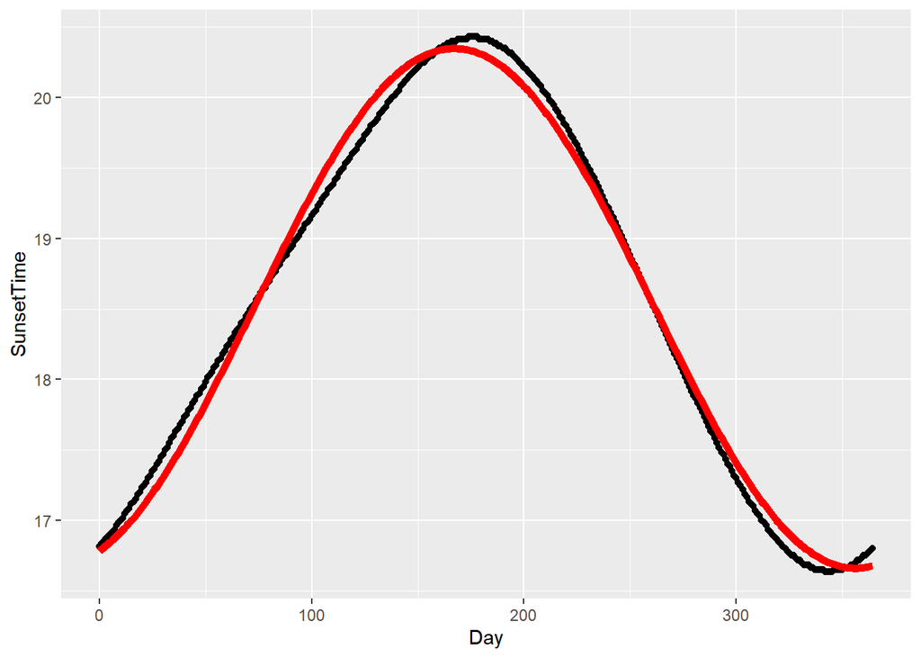

```r
start_d2 <- (max(suntimes$SunsetTime)+min(suntimes$SunsetTime))/2
start_a2 <- max(suntimes$SunsetTime)-start_d2
start_b2 <- 1/((2*pi)*9.24)
start_c2 <- 7.48 #used desmos to put minimum at Day 343, as can be seen in the dataset

mod.cyc.sunset <- nls(SunsetTime ~ a * sin((b * Day) + c) + d,data=suntimes,start=list(a=start_a2,b=start_b2,c=start_c2,d=start_d2))

suntimes$sunset_predicted <- predict(mod.cyc.sunset)

ggplot(suntimes,mapping=aes(x=Day,y=SunsetTime)) +
  geom_point() +
  geom_line(mapping=aes(x=Day,y=sunset_predicted),color="red",linewidth=2)
```

## Conclusion

Cyclic Models are used to model trends over time that repeat themselves over a given period, usually with input time $t$. We use the function $y=a\sin(bt-c)+d$ to model this, where *a* is the amplitude, *b* is the period multiplier, *c* is the horizontal shift, and *d* is the vertical shift. We use nls() to map this, and the starting values must be thought of strategically to get the best possible fit for the trend, keeping in mind a logical period, as well as minimums and maximums from the input dataset.